# Analisis Segmentasi Pelanggan Berbasis RFM pada Database Sakila Menggunakan K-Means Clustering

## 7.5 Analisis Korelasi RFM

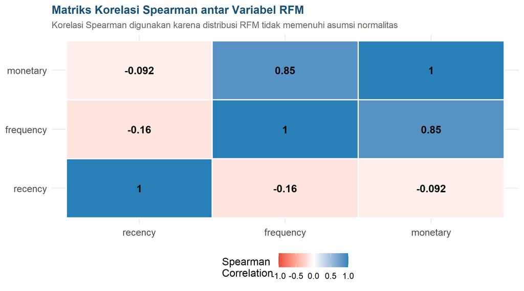

```r
# Hitung RFM sementara untuk korelasi (sebelum normalisasi)
recency_tmp <- rental %>%
  group_by(customer_id) %>%
  summarise(last_rental = max(rental_date, na.rm = TRUE), .groups = "drop") %>%
  mutate(recency = as.numeric(difftime(ref_date, last_rental, units = "days")))

frequency_tmp <- rental %>%
  group_by(customer_id) %>%
  summarise(frequency = n(), .groups = "drop")

monetary_tmp <- payment %>%
  group_by(customer_id) %>%
  summarise(monetary = sum(amount, na.rm = TRUE), .groups = "drop")

rfm_tmp <- recency_tmp %>%
  inner_join(frequency_tmp, by = "customer_id") %>%
  inner_join(monetary_tmp,  by = "customer_id") %>%
  select(recency, frequency, monetary)

cor_mat <- cor(rfm_tmp, method = "spearman")

cor_long <- as.data.frame(as.table(cor_mat)) %>%
  rename(Var1 = Var1, Var2 = Var2, corr = Freq)

ggplot(cor_long, aes(x = Var1, y = Var2, fill = corr)) +
  geom_tile(color = "white", linewidth = 0.8) +
  geom_text(aes(label = round(corr, 3)), size = 4.5, fontface = "bold") +
  scale_fill_gradient2(low = "#e74c3c", mid = "white", high = "#2980b9",
                       midpoint = 0, limits = c(-1, 1),
                       name = "Spearman\nCorrelation") +
  labs(title    = "Matriks Korelasi Spearman antar Variabel RFM",
       subtitle = "Korelasi Spearman digunakan karena distribusi RFM tidak memenuhi asumsi normalitas",
       x = NULL, y = NULL) +
  theme(axis.text = element_text(size = 12))
```

# 8 Perhitungan Skor RFM

## 8.1 Definisi Formal

$$\text{Recency}(c) = T_{\text{ref}} -
\max_{i: \text{cust}_i = c}\{T_{\text{rental},i}\} \quad
\text{(hari)}$$

$$\text{Frequency}(c) = \left|\{i :
\text{cust}_i = c\}\right| \quad \text{(jumlah transaksi)}$$

$$\text{Monetary}(c) = \sum_{i:
\text{cust}_i = c} \text{amount}_i \quad \text{(USD)}$$

di mana $T_{\text{ref}}$ adalah tanggal referensi (T+1 dari transaksi terakhir), dan $c$ adalah identitas pelanggan.

```r
# Recency: jarak hari dari tanggal referensi
recency_df <- rental %>%
  group_by(customer_id) %>%
  summarise(last_rental = max(rental_date, na.rm = TRUE), .groups = "drop") %>%
  mutate(recency = as.numeric(difftime(ref_date, last_rental, units = "days")))

# Frequency: jumlah transaksi rental
frequency_df <- rental %>%
  group_by(customer_id) %>%
  summarise(frequency = n(), .groups = "drop")

# Monetary: total pembayaran kumulatif
monetary_df <- payment %>%
  group_by(customer_id) %>%
  summarise(monetary = sum(amount, na.rm = TRUE), .groups = "drop")

# Gabungkan — inner_join memastikan hanya pelanggan dengan ketiga data lengkap
rfm <- recency_df %>%
  inner_join(frequency_df, by = "customer_id") %>%
  inner_join(monetary_df,  by = "customer_id") %>%
  select(customer_id, recency, frequency, monetary)

cat(sprintf("Pelanggan dengan RFM lengkap: %d\n", nrow(rfm)))
```

```
## Pelanggan dengan RFM lengkap: 599
```

## 8.2 Statistik Deskriptif RFM

```r
# Statistik deskriptif dengan tambahan SD dan CV
rfm_desc <- rfm %>%
  select(recency, frequency, monetary) %>%
  summarise(across(everything(), list(
    Min    = min,
    Q1     = ~quantile(., 0.25),
    Median = median,
    Mean   = mean,
    Q3     = ~quantile(., 0.75),
    Max    = max,
    SD     = sd,
    CV     = ~round(sd(.) / mean(.), 3)
  ), .names = "{.col}__{.fn}")) %>%
  pivot_longer(everything(), names_to = c("Variabel", "Statistik"),
               names_sep = "__") %>%
  pivot_wider(names_from = Statistik, values_from = value) %>%
  mutate(across(where(is.numeric), ~round(., 2)))

rfm_desc %>%
  kable(caption = "Statistik Deskriptif Tiga Dimensi RFM") %>%
  kable_styling(bootstrap_options = c("striped", "hover", "condensed"),
                full_width = FALSE)
```

Statistik Deskriptif Tiga Dimensi RFM

| Variabel | Min | Q1 | Median | Mean | Q3 | Max | SD | CV |
| --- | --- | --- | --- | --- | --- | --- | --- | --- |
| recency | 1.00 | 1.00 | 176.02 | 130.28 | 176.70 | 182.61 | 77.45 | 0.59 |
| frequency | 12.00 | 23.00 | 26.00 | 26.78 | 30.00 | 46.00 | 5.11 | 0.19 |
| monetary | 50.85 | 94.78 | 110.73 | 112.53 | 128.71 | 221.55 | 25.37 | 0.22 |

**Catatan pola Recency:** Nilai Recency memperlihatkan struktur yang tidak seragam: sebagian pelanggan memiliki Recency sangat rendah (transaksi sangat baru, sekitar 1 hari), sementara sebagian lain memiliki Recency sangat tinggi (sekitar 176–183 hari, menandakan tidak aktif dalam kurang lebih 6 bulan). Pola ini merupakan konsekuensi dari struktur historis database Sakila yang mencatat dua periode aktivitas transaksi yang terpisah (Mei–Agustus 2005 dan Februari 2006). Hal ini perlu diperhatikan dalam interpretasi hasil clustering, mengingat pola ini tidak selalu mencerminkan perilaku pelanggan yang organik pada bisnis nyata.

## 8.3 Distribusi Tiga Dimensi RFM

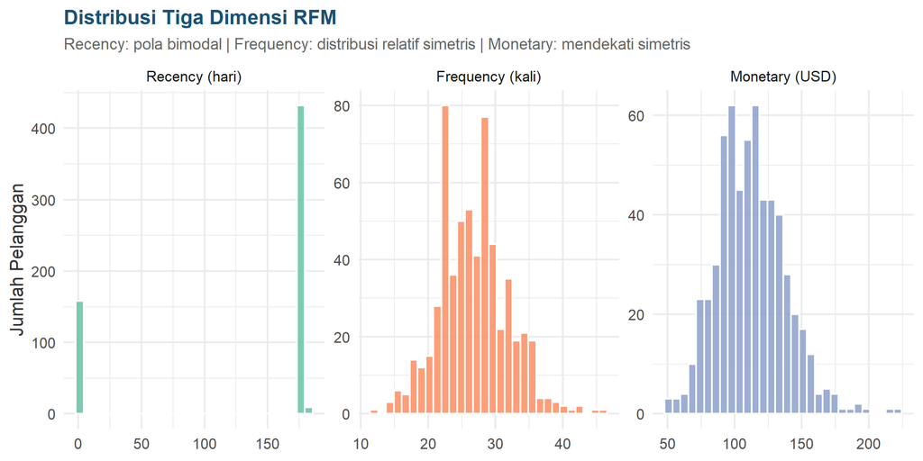

```r
rfm_long <- rfm %>%
  select(recency, frequency, monetary) %>%
  pivot_longer(everything(), names_to = "metrik", values_to = "nilai") %>%
  mutate(metrik = factor(metrik,
                         levels = c("recency", "frequency", "monetary"),
                         labels = c("Recency (hari)", "Frequency (kali)", "Monetary (USD)")))

ggplot(rfm_long, aes(x = nilai, fill = metrik)) +
  geom_histogram(bins = 30, color = "white", alpha = 0.85, show.legend = FALSE) +
  facet_wrap(~metrik, scales = "free", nrow = 1) +
  scale_fill_brewer(palette = "Set2") +
  labs(title    = "Distribusi Tiga Dimensi RFM",
       subtitle = "Recency: pola bimodal | Frequency: distribusi relatif simetris | Monetary: mendekati simetris",
       x = NULL, y = "Jumlah Pelanggan")
```

## 8.4 Boxplot dan Deteksi Outlier

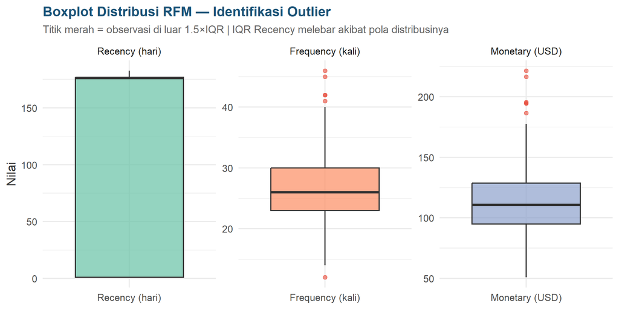

```r
ggplot(rfm_long, aes(x = metrik, y = nilai, fill = metrik)) +
  geom_boxplot(alpha = 0.7, outlier.color = "#e74c3c",
               outlier.alpha = 0.6, outlier.size = 1.8,
               show.legend = FALSE) +
  facet_wrap(~metrik, scales = "free", nrow = 1) +
  scale_fill_brewer(palette = "Set2") +
  labs(title    = "Boxplot Distribusi RFM — Identifikasi Outlier",
       subtitle = "Titik merah = observasi di luar 1.5×IQR | IQR Recency melebar akibat pola distribusinya",
       x = NULL, y = "Nilai")
```

# 9 Normalisasi Data

## 9.1 Justifikasi Min-Max Scaling

K-Means menggunakan jarak Euclidean sebagai ukuran kemiripan antar observasi. Tanpa normalisasi, variabel dengan satuan dan rentang nilai yang lebih besar akan mendominasi perhitungan jarak, sehingga kontribusi variabel lain menjadi relatif kecil. Dalam kasus ini, Recency dalam satuan hari berpotensi mendominasi jika tidak dinormalisasi.

Min-Max scaling mentransformasi setiap variabel ke rentang [0, 1]:

$$x_{\text{norm}} = \frac{x -
x_{\min}}{x_{\max} - x_{\min}}$$

Khusus untuk Recency, nilai hasil transformasi dibalik menjadi $r_{\text{norm}} = 1 - \text{MinMax}(R)$, sehingga nilai yang mendekati 1 merepresentasikan pelanggan dengan transaksi lebih baru — konsisten dengan konvensi RFM di mana skor lebih tinggi mencerminkan kondisi yang lebih menguntungkan secara bisnis.

Perlu diperhatikan bahwa Min-Max scaling sensitif terhadap nilai ekstrem (outlier), karena menggunakan nilai minimum dan maksimum sebagai acuan. Jika terdapat outlier pada data, rentang normalisasi dapat menjadi sangat lebar dan memampatkan sebagian besar data ke area sempit.

```r
normalize <- function(x) (x - min(x)) / (max(x) - min(x))

rfm_scaled <- rfm %>%
  mutate(
    r_norm = 1 - normalize(recency),   # dibalik: recency kecil = lebih baik
    f_norm = normalize(frequency),
    m_norm = normalize(monetary)
  )

rfm_matrix <- rfm_scaled %>%
  select(r_norm, f_norm, m_norm) %>%
  as.matrix()

cat(sprintf("Dimensi matrix input: %d baris × %d kolom\n", nrow(rfm_matrix), ncol(rfm_matrix)))
```

```
## Dimensi matrix input: 599 baris × 3 kolom
```

```r
cat(sprintf("r_norm: %.3f – %.3f\n", min(rfm_matrix[,1]), max(rfm_matrix[,1])))
```

```
## r_norm: 0.000 – 1.000
```

```r
cat(sprintf("f_norm: %.3f – %.3f\n", min(rfm_matrix[,2]), max(rfm_matrix[,2])))
```

```
## f_norm: 0.000 – 1.000
```

```r
cat(sprintf("m_norm: %.3f – %.3f\n", min(rfm_matrix[,3]), max(rfm_matrix[,3])))
```

```
## m_norm: 0.000 – 1.000
```

# 10 Penentuan Jumlah Cluster Optimal

## 10.1 Metode Elbow (WSS)

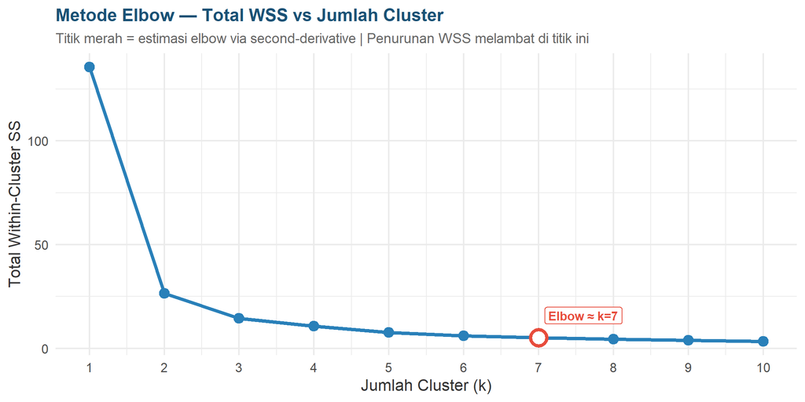

```r
set.seed(123)
wss <- map_dbl(1:10, ~{
  kmeans(rfm_matrix, centers = .x, nstart = 25, iter.max = 100)$tot.withinss
})

elbow_df <- tibble(k = 1:10, wss = wss)

# Estimasi elbow via second-derivative WSS
delta1  <- diff(wss)
delta2  <- diff(delta1)
k_elbow <- which.min(delta2) + 1

ggplot(elbow_df, aes(x = k, y = wss)) +
  geom_line(color = "#2980b9", linewidth = 1.3) +
  geom_point(size = 3.5, color = "#2980b9") +
  geom_point(data = elbow_df[k_elbow, ], size = 5,
             shape = 21, color = "#e74c3c", fill = "white", stroke = 2) +
  annotate("label", x = k_elbow + 0.6, y = wss[k_elbow] + diff(range(wss)) * 0.08,
           label = paste0("Elbow ≈ k=", k_elbow),
           color = "#e74c3c", size = 3.5, fontface = "bold") +
  scale_x_continuous(breaks = 1:10) +
  scale_y_continuous(labels = comma) +
  labs(title    = "Metode Elbow — Total WSS vs Jumlah Cluster",
       subtitle  = "Titik merah = estimasi elbow via second-derivative | Penurunan WSS melambat di titik ini",
       x = "Jumlah Cluster (k)", y = "Total Within-Cluster SS")
```

**Interpretasi WSS:** Dari k=1 ke k=2, terlihat penurunan WSS yang cukup besar — hal ini konsisten dengan adanya dua kelompok yang terbentuk dari perbedaan pola Recency. Setelah k=2, penurunan WSS relatif lebih landai. Pola ini memberikan indikasi awal bahwa k=2 mungkin merupakan pilihan yang efisien, meskipun interpretasi titik elbow tetap memiliki unsur subjektif dan perlu dikonfirmasi dengan metode validasi lain.